# Test de Normalité de Shapiro-Wilk

Olivier

# 1 Objectif

Tester si un échantillon pourrait être issue d’une population relevant d’un Loi Normale.

## 1.1 Utilisation

- La Normalité est une des Conditions d’application du test de Student

## 1.2 voir

- help(shapiro)
- Wiki
- Formules :

## 1.3 Lecture du Test :

### 1.3.1 Interprétation naïve

si p-value < 0,0.5 : il est peu probable que la distribution de l’échantillon suive une Loi Normale. si p > 0,05 : il est possible que l’échantillon suivent une Loi Normale

### 1.3.2 Interprétation plus juste

#### 1.3.2.1 Hypothèse Nulle

l’Hypothèse nulle est que la population testée suive une Loi Normale. Le Test de Shapiro test cette hypothèse nulle. p-valeur représente la probalilité que la population dont est issue l’échantillon suive une Loi Normale. Si elle est inférieure à 5% on rejette l’hypothèse nulle (trop faible probabilité d’être issue d’une loi Normale)

## 1.4 Exemples / Illustrations

### 1.4.1 Exemple 1 : Une Distribution Normale

Par définition, une distribution Normale générée par R devrait “être Normale” :

```r
distribution <- rnorm(5000, mean = 50, sd = 3)
```

##### 1.4.1.0.1 Allure ?

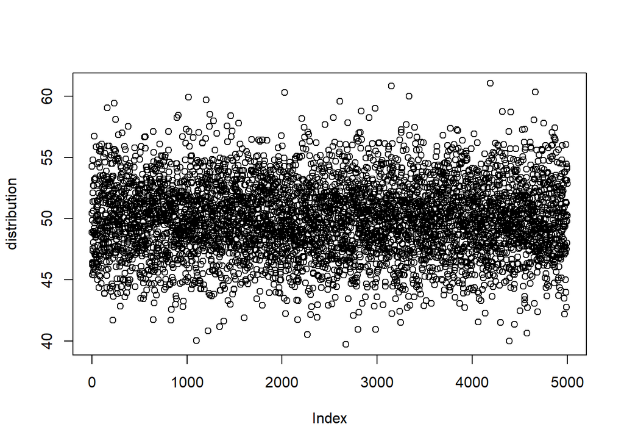

```r
plot(distribution)
```

On voit bien qu’un plot ne nous apporte pas grand chose :  
tout au plus, les points semblent etre plus nombreux autour de 50 et moins nombreux quand on s’éloigne de 50.

plot de Densité

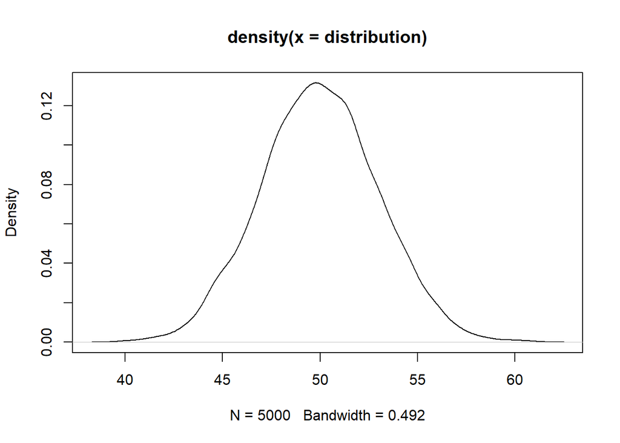

```r
plot(density(distribution))
```

##### 1.4.1.0.2 Histograme

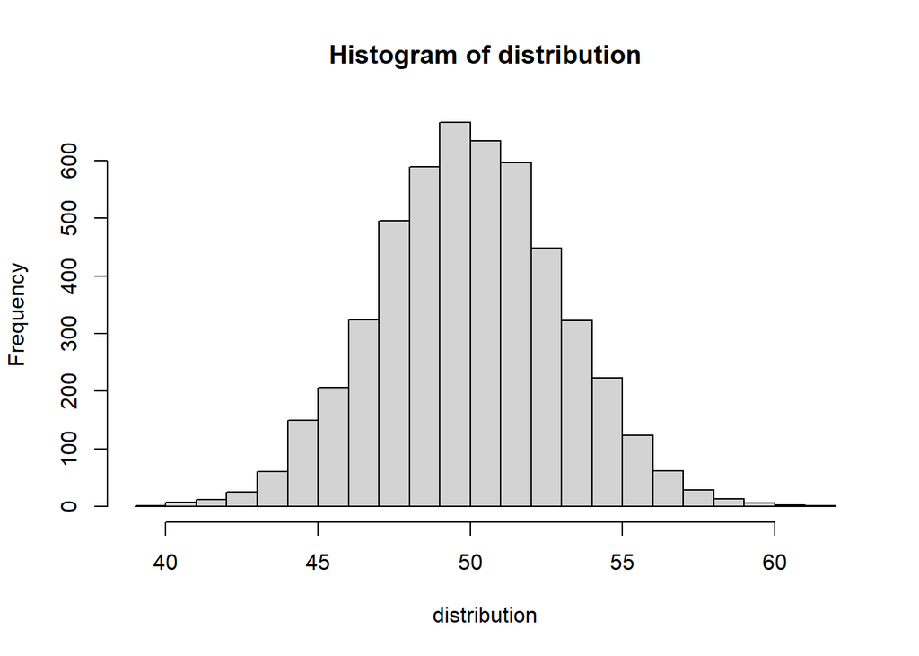

```r
hist(distribution, nclass=20)
```

Ca ressemble effectivement bien à une Loi Normale.

Que nous dit le Test de Shapiro-Wilk ?

```r
shapiro.test(distribution)
```

```
##
##  Shapiro-Wilk normality test
##
## data:  distribution
## W = 0.99969, p-value = 0.6765
```

Il serait intéressant de faire 1000 échantillons de 500 tirages au hasard (TODO), on s’apercevrait probablement que la probabitité de d’accepter sous Ho formerait une courbe de Gauss

```r
distribution <- rnorm(5000, mean = 50, sd = 3)
shapiro.test(distribution)
```

```
##
##  Shapiro-Wilk normality test
##
## data:  distribution
## W = 0.99977, p-value = 0.8923
```

```r
distribution <- rnorm(500, mean = 50, sd = 3)
shapiro.test(distribution)
```

```
##
##  Shapiro-Wilk normality test
##
## data:  distribution
## W = 0.994, p-value = 0.04552
```

### 1.4.2 Exemple 2 : Une Séquence Croissante

Une suite de nombres croissants pourrait-elle relever d’une Loi Normale ?

```r
sequence <- seq(-10, 10, length=500)
```

##### 1.4.2.0.1 Allure ?

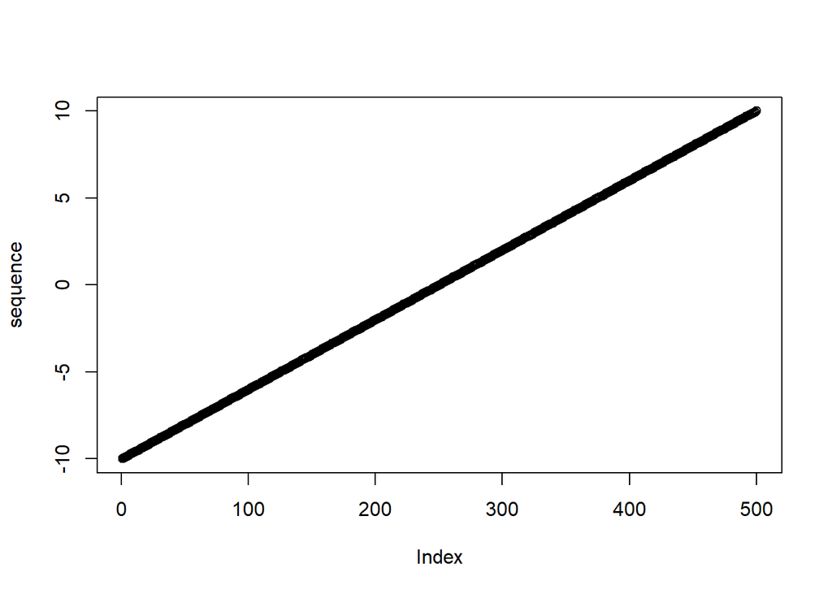

```r
plot(sequence)
```

Histograme

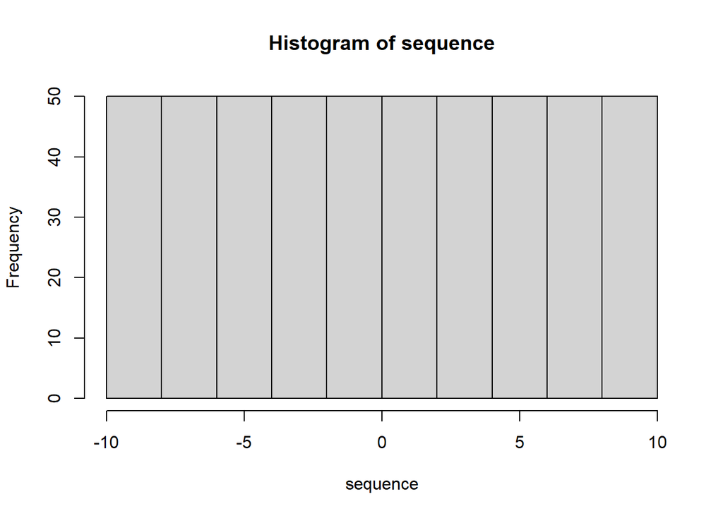

```r
hist(sequence, nclass=10)
```

### 1.4.3 Exemple 3 : Une Séquence Croissante de 50 valeurs

Une suite de nombres croissants pourrait-elle relever d’une Loi Normale ?

```r
sequence <- seq(-10, 10, le=50)
```

##### 1.4.3.0.1 Allure ?

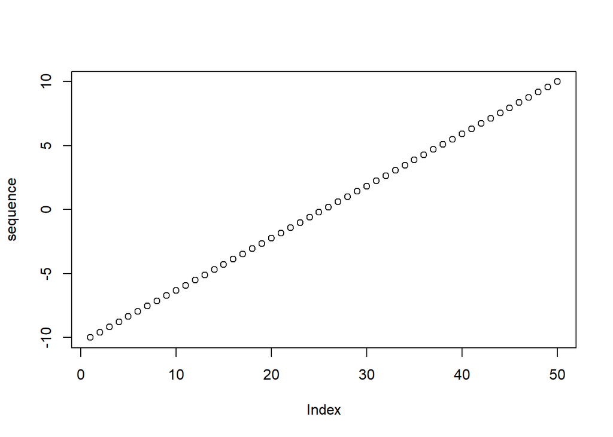

```r
plot(sequence)
```

A première vue, ça semble peut problable…mais sait-on jamais… ATTENTION : NE PAS ATTENDRE QUE LE PLOT ait l’allure d’une courbe de Gauss…ce n’est pas une distribution => C’est un histogramme qu’il faut faire ici :

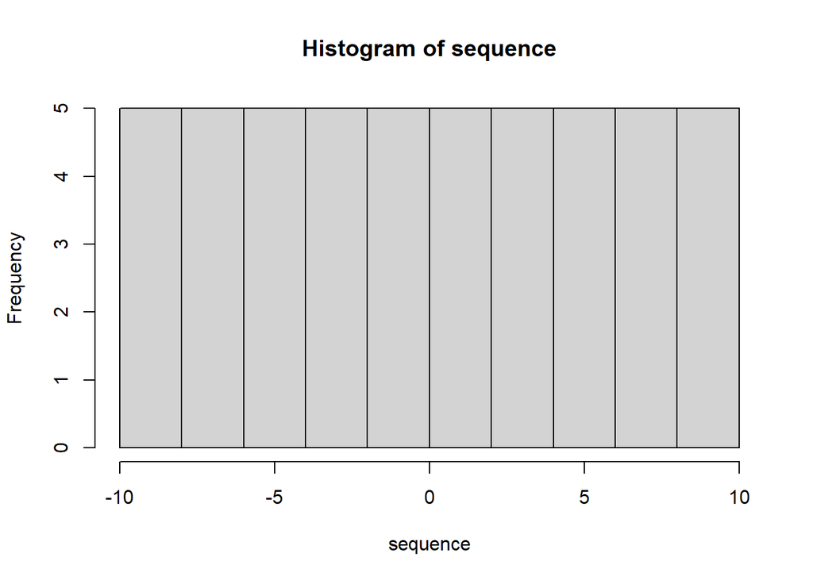

```r
hist(sequence, nclass=10)
```

Définitivement très peu probable, qu’est-ce que nous dit le test de Shapiro ?

##### 1.4.3.0.2 Vérification du Test de Shapiro ?

```r
shapiro.test(sequence)
```

```
##
##  Shapiro-Wilk normality test
##
## data:  sequence
## W = 0.95558, p-value = 0.05809
```

Le Test de Shapiro ne permet pas de rejeter l’hypothèse nulle (Ho) avec un risque alpha de 5%  
(puisque le p-value n’est pas inférieure à 0,05)

On doit donc accepter Ho avec un risque beta.

#### 1.4.3.1 Discussion des résultats :

1. Accepter l’Hypothèse nulle (Ho : La distribution = Loi Normale) n’est pas une PREUVE que l’échantillon est normal. Mais on ne peut pas être certain du contraire.
2. Le risque d’accepter Ho à tord (ici dire que l’échantillon “est Normal”), est d’autant plus grand que l’échantillon est petit (ici n=50 manque encore un peu de puissance).
3. En plus de la faible taille de l’échantillon, le fait que la séquence soit uniformément répartie *doit majorer le risque de tromper le test de Shapiro* (A VERIFIER : TODO)

## 1.5 FAIRE une Test avec une distribution très dyssymétrique

# 2 JEU : Essayer de trouver des distributions qui ont les plus mauvais scores de Shapiro

```r
# Paramètres de la distribution bêta
alpha <- 10   # Ajustez les paramètres pour créer une dissymétrie
beta <- 1
# Générer un échantillon de la distribution bêta
echantillon <- rbeta(1000, shape1 = alpha, shape2 = beta) # W = 0.86346


# Paramètres de la distribution gamma
shape <- 2   # Ajustez les paramètres pour créer une dissymétrie
scale <- 11
# Générer un échantillon de la distribution gamma
echantillon <- rgamma(1000, shape = shape, scale = scale) # => W = 0.88675

# Générer un échantillon de la distribution exponentielle
echantillon <- rexp(1000, rate = 2)  # "rate" est l'inverse de la moyenne, ajustez-le selon vos besoins
# shapiro.test(echantillon)  # Résultat qui oscillent entre W = 0.76 et W = 0.85

# Générer un échantillon d'une distribution t avec 3 degrés de liberté
echantillon <- rt(100, df = 1) # W = 0.77158

# Générer un échantillon d'une distribution normale
echantillon <- rnorm(1000)
# Ajouter 1 aux valeurs négatives
echantillon <- ifelse(echantillon < 0, echantillon + 5, echantillon)
# Courbe en U... mais encore une score de W = 0.85944
```

### 2.0.1 Meilleur Réponse trouvée:

Des Distributions de Chi2 à 1 degré de liberté

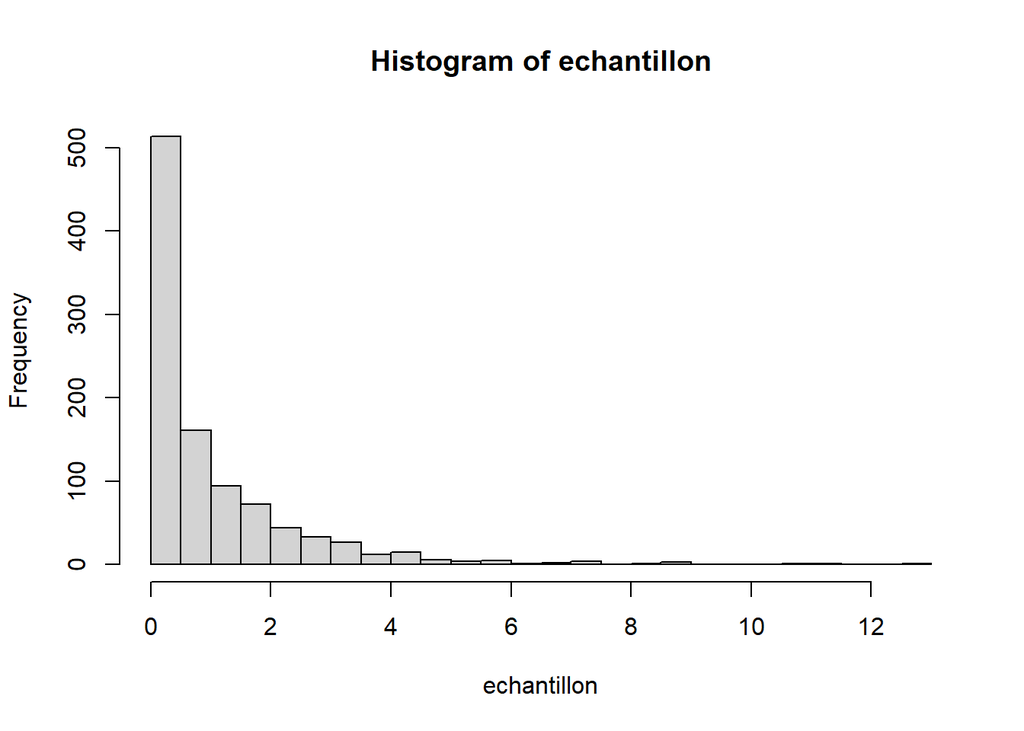

```r
# Générer un échantillon d'une distribution chi-carré avec 3 degrés de liberté
echantillon <- rchisq(1000, df = 1) # Best W = 0.65 Pas mal

hist(echantillon, nclass= 20)
```

```r
shapiro.test(echantillon)
```

```
##
##  Shapiro-Wilk normality test
##
## data:  echantillon
## W = 0.68557, p-value < 2.2e-16
```

# 3 A Retenir

# 4 S’entraîner :

- TDR31 : Comparaison de Moyennes sous R

# 5 Sources